# Cross-Rate Equilibria and Monetary Transmission

Shirine Megueddem, Tony De Amorim

2025-05-14

## 1 Introduction

Pour ce projet, nous nous intéressons au lien entre le taux de change entre la couronne sudéoise et l’Euro. Au niveau du code, voici les packages utilisés et les options de personnalisation de graphiques mobilisés :

```r
knitr::opts_chunk$set(echo = TRUE)
library(readxl)
library(corrplot)
library(gridExtra)
library(ggplot2)
library(showtext)
library(stargazer)
showtext_auto()
font_add_google("Lato", "lato")

theme_set(
  theme_minimal(base_family = "lato") +
    theme(
      plot.title = element_text(size = 16, face = "bold"),
      plot.subtitle = element_text(size = 12),
      axis.title = element_text(size = 12),
      axis.text = element_text(size = 10),
      plot.caption = element_text(size = 9, hjust = 1, face = "italic")
    )
)
```

## 2 Interprétation économique

Le lien entre taux d’intérêt et taux de change est un lien indirect, qui passe par les flux de capitaux. Si les taux domestiques augmentent, les capitaux étrangers affluent, ce qui apprécie la monnaie nationale. Inversement, des taux plus faibles entraînent une fuite des capitaux, et donc une dépréciation de la monnaie nationale.

Ce lien concerne principalement les taux **courts**, pilotés par les banques centrales.

L’investisseur compare la rentabilité d’un placement local à celle d’un placement étranger corrigé des variations anticipées du taux de change. Il s’agit de la **parité non couverte des taux d’intérêt (UIP)** : une différence de taux d’intérêt entre deux pays est compensée par une variation anticipée du taux de change. Ainsi, une devise dont le rendement est plus élevé est censée se déprécier dans le futur pour que l’arbitrage soit nul entre les deux zones.

La différence de taux d’intérêt nominaux est égale à l’appréciation attendue du taux de change nominal :

$$i_d - i_e = \frac{\Delta e}{e}$$

où : - $i_d$ est le taux d’intérêt nominal domestique  
- $i_e$ est le taux d’intérêt nominal étranger  
- $\frac{\Delta e}{e}$ est l’appréciation attendue du taux de change nominal

En intégrant l’inflation (donc en **taux réels**), la différence de taux réels est égale à l’appréciation attendue du taux de change réel :

$$r_d - r_e = \frac{\Delta q}{q}$$

où : - $r_d$ est le taux d’intérêt réel domestique  
- $r_e$ est le taux d’intérêt réel étranger  
- $\frac{\Delta q}{q}$ est l’appréciation attendue du taux de change réel

Cependant, ce lien est **théorique**, et est souvent **non vérifié en réalité**.

Un exemple : le **forward premium anomaly**. Il s’agit du résultat empirique suivant : la valeur de la monnaie domestique augmente lorsque les taux d’intérêt nominaux domestiques dépassent les taux étrangers, et inversement.

Concernant les différents types de taux : - **Les taux courts**, pilotés par les banques centrales.  
- **Les taux longs**, influencés par le marché, intègrent les anticipations d’inflation, de croissance, et de prime de risque.  
- **Les taux moyens**, de maturité entre 1 et 5 ans, sont sensibles aux anticipations à court-moyen terme.

La **courbe des taux** reflète les anticipations de marché sur les taux à différentes maturités : - Une **pente positive** indique des anticipations de croissance et de resserrement monétaire → renforce la devise.  
- Une **pente inversée** est perçue comme un signal de récession → affaiblit la devise.

Ce lien entre taux d’intérêt, mouvements de capitaux et taux de change s’inscrit aussi dans le cadre du **triangle d’incompatibilité de Mundell** : en régime de **libre circulation des capitaux**, un pays ne peut avoir **à la fois** un taux de change fixe **et** une politique monétaire autonome.

La **Suède** et la **zone euro** ont un régime de **change flottant**, ce qui leur permet d’ajuster indépendamment leurs taux directeurs face aux chocs économiques, influençant ainsi directement le taux de change **EUR/SEK** via les écarts de taux d’intérêt.

**Application à notre projet** : - Une **courbe des taux positive en Suède** reflète des anticipations de croissance et de resserrement monétaire → attire les capitaux → **appréciation du SEK** → **baisse du taux de change EUR/SEK**.  
- Une **courbe inversée en zone euro** peut signaler une future baisse des taux directeurs → **baisse de l’attractivité de l’euro** → dépréciation face au SEK.

## 3 Collecte des données et premières analyses empiriques

### 3.1 Sélection des données

Après étude de nos données, nous avons décidé d’utiliser les taux d’intérêt pour des maturités à 2 et 10 ans. Ce choix provient d’une part des données disponibles (nottament pour la couronne sudéoise) et d’autre part de la significativité plus importante après test du taux à 10 ans en comparaison de ceux à 7ans et 20 ans

D’autre part, pour éviter la stationnarité de nos données nous avons décidé de sélectionner une période s’étallant de 2007 à 2017. Après visualisation de nos données dans le temps, nous avons observé que cette période représentait le plus de stabilité sur l’ensemble de nos données, c’est pourquoi nous l’avons selectionné. Nous avons récupéré nos données en journalier et après avoir utilisé la fonction aggregate() nous obtenons des séries de 132 observations mensuelles.

Enfin, nous avons crée deux nouvelles séries correspondant aux pentes respective des courbes des taux europénne et suédoise.

### 3.2 Graphiques

Dans un premier temps nous représentons graphiquement nos différentes variables en fonction du taux de change sur la période 2007 - 2017

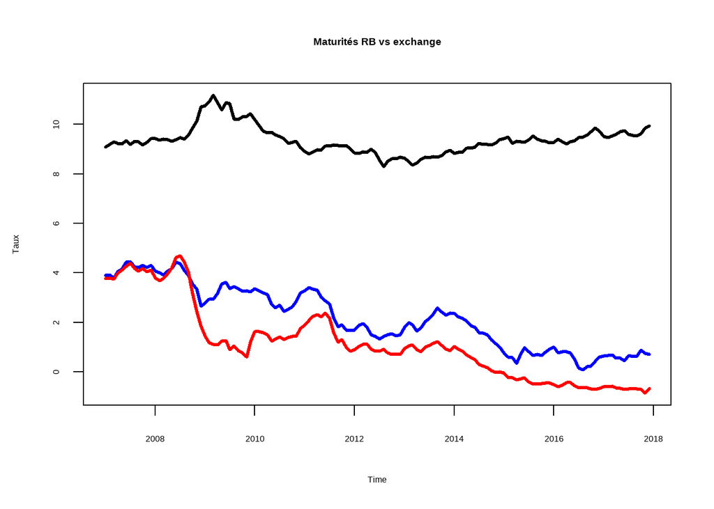

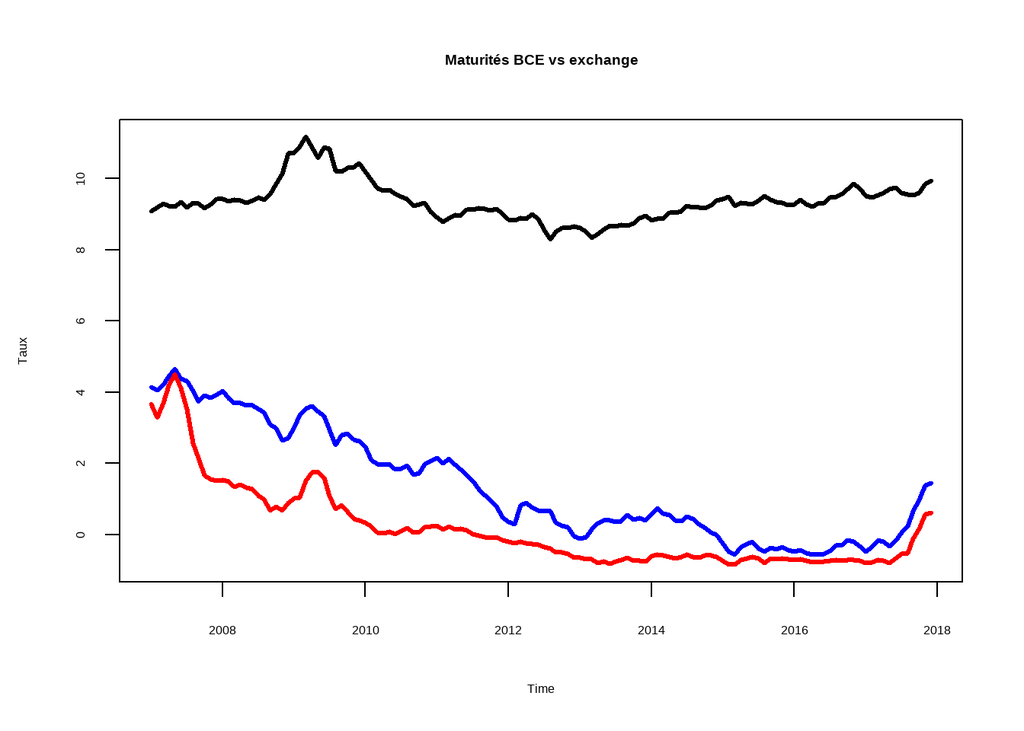

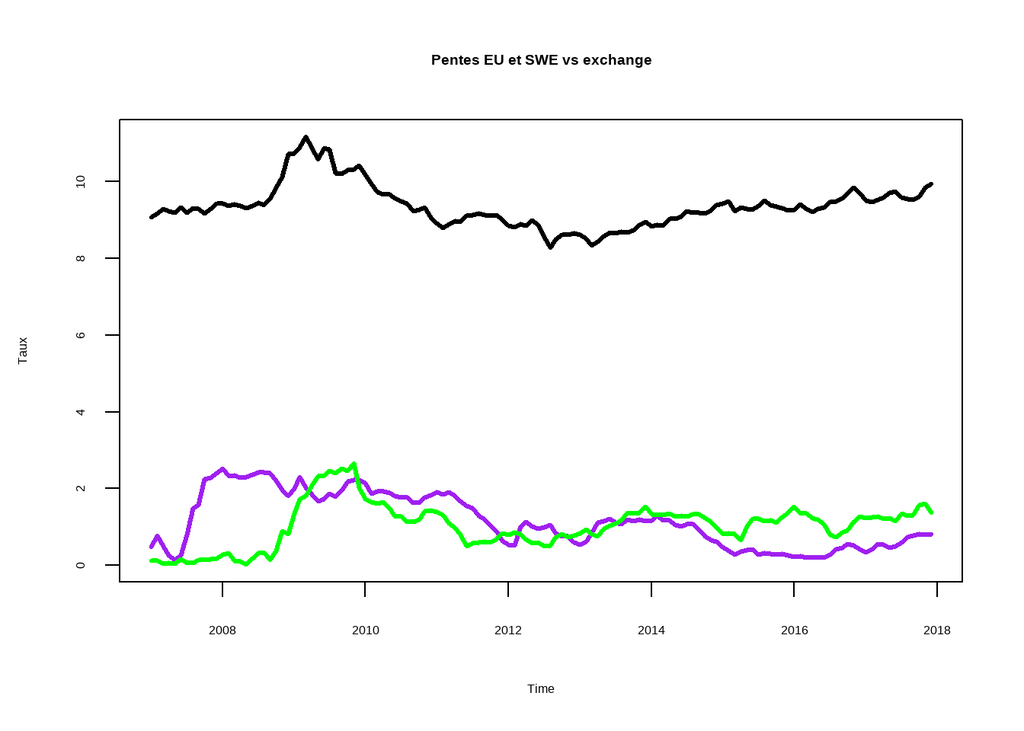

Tel que : Noire = Taux de change SEK contre Euro Bleu = Taux à 10 ans Rouge = Taux à 2 ans Violet = Pente BCE Vert = Pente Suédoise

### 3.3 Matrice des corrélations

On représente ici le corrélograme entre nos différentes variables.

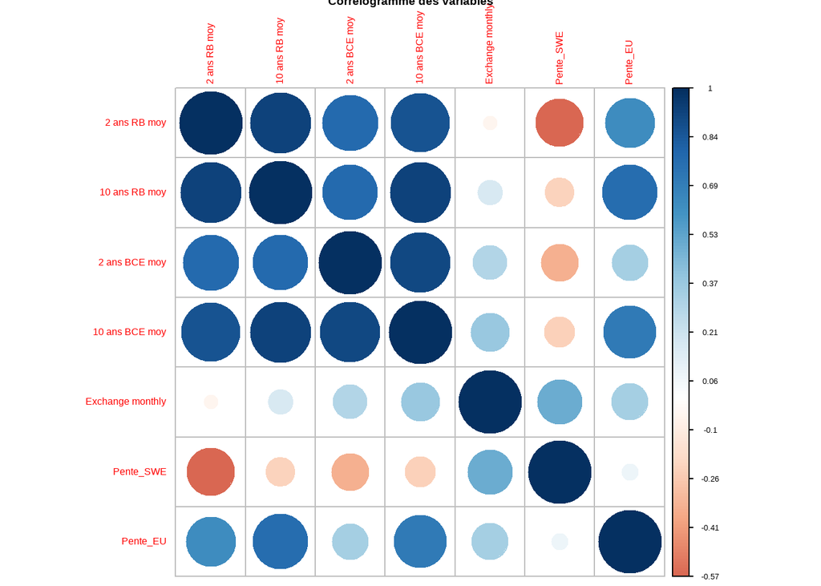

Notre graphique nous donne plusieurs informations intéressantes. Il existe par exemple une forte corrélation des taux entre eux, ce qui fait sens du fait de la proximité des deux économies étudiées. Ensuite, le lien entre taux de change et taux d’intérêt brut est loin d’être avéré. La relation semble néanmoins s’intensifier lorsque l’on utilise plutôt la pente de la courbe des taux pour la comparaison.

Nous ne pouvons arréter notre analyse à ces résultats. En effet, cette matrice des corrélations n’est qu’une moyenne des corrélations sur la période et ne prend pas en compte les fluctuations des politiques des banques centrales en fonction de la conjecture économique. L’hypothèse de stationarité de nos séries n’étant pas réaliste, il semblerait pertinent d’introduire du dynamisme à notre modèle, nottament en utilisant des corrélations glissantes.

### 3.4 Corrélations glissantes

Nous avons ici codé une fonction permettant de réaliser des corrélations glissantes :

```r
# On prend trois valeurs en paramètres : la dépendante, l'explicative et le pas de glissement
corr_glissante <- function(y,x,step){
  n <- length(x) # on initialise n au nombre d'observations
  result <- numeric(n - step + 1) # on crée un vecteur de 0 pour accueillir nos valeurs finales
  for (i in 1:(n-step+1)) { # on parcourt nos deux variables
    var1 <- y[i:(i+step-1)] # on obtient un segment de valeurs égal au pas de glissement
    var2 <- x[i:(i+step-1)] # on obtient un segment de valeurs égal au pas de glissement
    # on calcule la corrélation
    result[i] <- cor(var1,var2, use = "complete.obs", method = "pearson")
  }
  return(result)
}
```

Est-ce que utiliser des corrélations glissantes permet de dépasser les limites de la matrice de corrélation statique ? Pour le vérifier nous avons donc calculé des corrélations glissantes entre les pentes des courbes de taux pour la Suède et la zone euro sur trois horizons : 6, 12 et 18 mois, ce qui nous donne les graphiques :

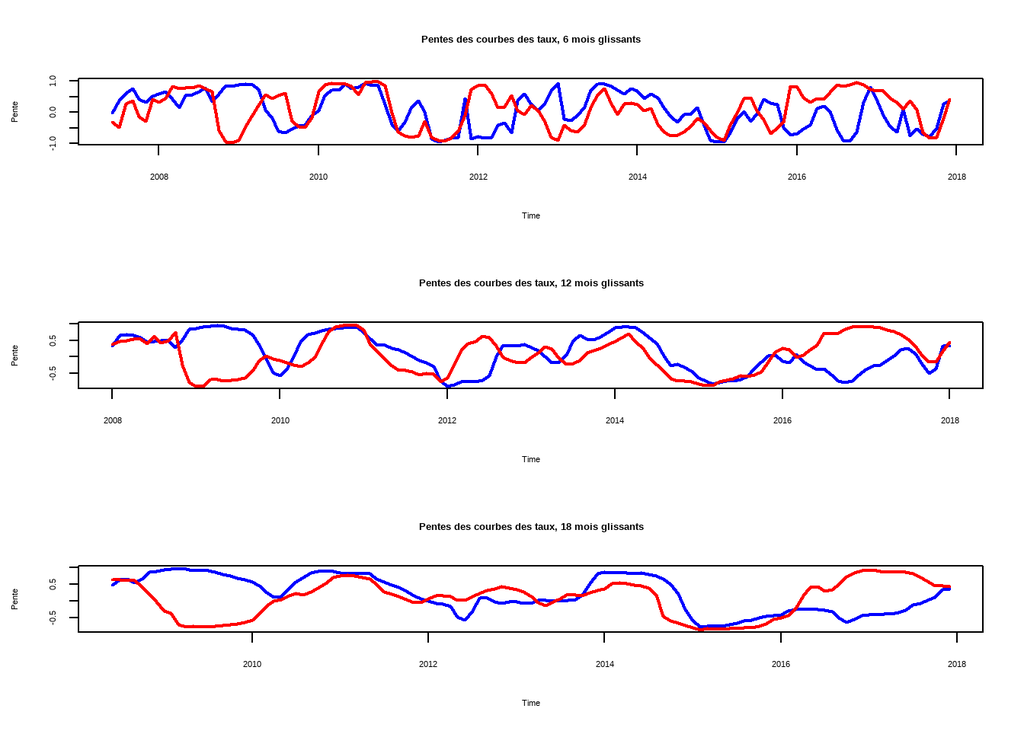

Nous en tirons les observations suivantes.

Sur 6 mois, la corrélation est très volatile avec des alternances fréquentes entre corrélations positives et négatives, reflètant une forte instabilité du lien de court terme entre les deux séries. Cela peut être dû à des chocs idiosyncratiques, propre à une seule des deux économies ou à des divergences ponctuelles de politiques monétaires.

Sur 12 mois, la courbe deviens plus régulière : les phases de corrélation positive/négative durent plus longtemps. Cela pourrait suggérer une certaine co-mobilité des pentes à moyen terme.

Comme attendu, ces résultats ne soutiennent pas l’idée d’une stabilité temporelle des relations économiques entre les pentes de taux suédoises et européennes : La corrélation n’est pas graphiquement stable dans le temps, en particulier sur les fenêtres courtes. La matrice de corrélation statique masque des dynamiques temporelles importantes, justifiant pleinement le recours à des corrélations mobiles pour mener une analyse empirique rigoureuse.

## 4 Modélisation

### 4.1 Modèle initiale

Nous modélisons ici l’équation :

$$\begin{equation}
(fx_{\text{SEK}/\text{EUR}})_t = \alpha + \beta \left(
r^{\text{long}}_{\text{SWE},t} - r^{\text{court}}_{\text{SWE},t} \right)
+ \varepsilon_t
\end{equation}$$

Après estimation nous obtenons :

**Résumés de la régression**

|  | *Dependent variable:* |
| --- | --- |
|  | `Exchange monthly` |
|  | Pente suèdoise |
| Pente_SWE | 0.5*** |
|  | (0.1) |
| Constant | 8.9*** |
|  | (0.1) |
| Observations | 132 |
| R<sup>2</sup> | 0.2 |
| Adjusted R<sup>2</sup> | 0.2 |
| F Statistic | 43.0*** (df = 1; 130) |
| *Note:* | p<0.1; p<0.05; p<0.01 |

et donc l’équation estimée :

$$\begin{equation}
(fx_{\text{SEK}/\text{EUR}})_t = 8.8599 + 0.4823 \left(
r^{\text{long}}_{\text{SWE},t} - r^{\text{court}}_{\text{SWE},t} \right)
+ \varepsilon_t
\end{equation}$$

Parmis les résultats notables :

- $\beta = 0.4823$ est positif et significatif au seuil de 1% : une augmentation de la pente de la courbe des taux suédoise est associée à une hausse du taux de change SEK/EUR, (càd une dépréciation de la SEK).
- $R^2 = 0.248$ : environ 25% de la variation du taux de change est expliquée par la pente, une valeur modéré mais acceptable dans un modèle ne comptant qu’une seule variable explicative.
- $F^* = 42.96$ et p-value $< 10^{-9}$ : la pente est significativement différente de 0, la relation est globalement significative
- $BP = 2.4899$ et $p-value = 0.1146 > 0.05$ : il n’y a pas de preuve d’hétéroscédasticité dans notre modèle
- $DW = 0.10664$ : indique une forte autocorrélation positive des résidus.

Ce qui nous permet ensuite de tracer la simulation statique de notre équation :

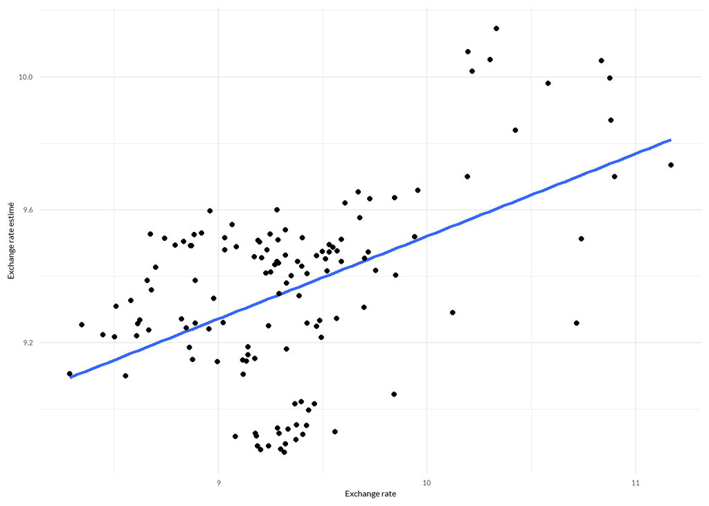

On observe que les points tendent à suivre une pente ascendante, ce qui indiquerait une relation positive estimée entre la pente des taux suédois et le taux de change SEK/EUR. Empiriquement, bien que le modèle ai ses failles, il confirmerait la relation entre taux de change et pente de la courbe de la courbe des taux.

### 4.2 Modèle complété

Nous nous intéressons désormais aux équations :

$$\begin{align}
(fx_{\text{SEK}/\text{EUR}})_t &= \alpha + \beta \left(
r^{\text{court}}_{\text{SWE},t} - r^{\text{court}}_{\text{UE},t} \right)
+ \varepsilon_t \\
(fx_{\text{SEK}/\text{EUR}})_t &= \alpha + \beta \left(
r^{\text{long}}_{\text{SWE},t} - r^{\text{long}}_{\text{UE},t} \right) +
\varepsilon_t
\end{align}$$

**Résumés des régressions**

|  | *Dependent variable:* |  |
| --- | --- | --- |
|  | `Exchange monthly` |  |
|  | Pente courte | Pente longue |
|  | (1) | (2) |
| pente_courte | -0.25*** |  |
|  | (0.05) |  |
| pente_longue |  | -0.56*** |
|  |  | (0.06) |
| Constant | 9.61*** | 9.84*** |
|  | (0.06) | (0.07) |
| Observations | 132 | 132 |
| R<sup>2</sup> | 0.19 | 0.38 |
| Adjusted R<sup>2</sup> | 0.18 | 0.37 |
| F Statistic (df = 1; 130) | 30.68*** | 78.12*** |
| *Note:* | p<0.1; p<0.05; p<0.01 |  |

Ce qui nous donne après estimation :

$$\begin{equation}
\left\{
\begin{aligned}
(fx_{\text{SEK}/\text{EUR}})_t &= 9.6119 - 0.2525 \left(
r^{\text{court}}_{\text{SWE},t} - r^{\text{court}}_{\text{UE},t} \right)
+ \varepsilon_t \\
(fx_{\text{SEK}/\text{EUR}})_t &= 9.8396 - 0.5623 \left(
r^{\text{long}}_{\text{SWE},t} - r^{\text{long}}_{\text{UE},t} \right) +
\varepsilon_t
\end{aligned}
\right.
\end{equation}$$

Les deux coefficients sont négatifs et hautement significatifs : une hausse du taux suédois relatif à celui de l’UE (qu’il soit court ou long) est associée à une appréciation de la SEK (donc baisse du taux SEK/EUR).

Pour le premier modèle (Différentiel de taux court) :

- $\beta = −0.2525$ : significatif à 1%
- $R^2 = 0.1909$ : 19.1% de la variance du taux de change expliquée par le modèle

Une hausse du différentiel de taux courts en faveur de la Suède (donc un $r_{SWE}^{court}$ plus élevé que celui de la BCE) est associée à une appréciation de la SEK (car le taux de change SEK/EUR baisse).

Pour le second (Différentiel de taux long) :

- $\beta = −0.5623$ : hautement significatif
- $R^2 = 0.3754$ : 37.5% de la variance expliquée par le modèle

L’impact du différentiel de taux longs est plus fort (coefficient plus élevé, meilleure qualité d’ajustement). Cela indiquerait que les investisseurs sont plus sensibles aux taux d’intérêt à long terme pour anticiper les mouvements du taux de change.

Et les simulations statiques :

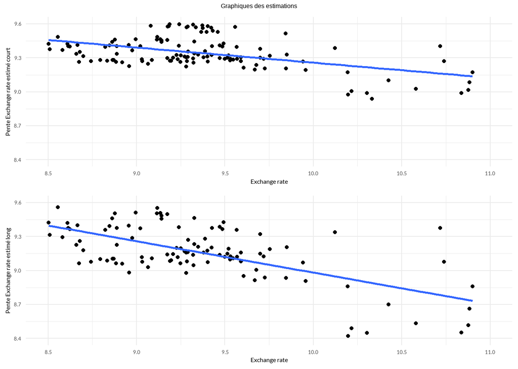

Les deux graphiques montrent une relation décroissante entre taux de change observé et valeurs estimées. La pente est cependant nettement plus marquée pour le différentiel de taux long confirmant que ce facteur explique davantage les mouvements du taux de change (le nuage de points est plus resserré autour de la droite dans le modèle long). Ainsi, nos modèles valides empiriquement l’influence sur le taux de change SEK/EUR exercé par les différentiels de taux d’intérêt, en particulier à long terme.

### 4.3 Ajout de variable

Nous avons ici décidé d’ajouter comme variables explicatives le prix du Brent en dollar par baril de pétrole pour mesurer l’impact du cours de l’énergie sur le change et le différentiel d’inflation entre les deux pays tel que :

$$\begin{align}
(fx_{\text{SEK}/\text{EUR}})_t &= \alpha + \beta \left(
r^{\text{long}}_{\text{SWE},t} - r^{\text{court}}_{\text{UE},t} \right)
+ \gamma_1 \cdot \text{OilPrice}_t + \gamma_2 \cdot \left|
\pi_{\text{SWE},t} - \pi_{\text{UE},t} \right| + \varepsilon_t \tag{5}
\\
(fx_{\text{SEK}/\text{EUR}})_t &= \alpha + \beta \left(
r^{\text{court}}_{\text{SWE},t} - r^{\text{court}}_{\text{UE},t} \right)
+ \gamma_1 \cdot \text{OilPrice}_t + \gamma_2 \cdot \left|
\pi_{\text{SWE},t} - \pi_{\text{UE},t} \right| + \varepsilon_t \tag{6}
\\
(fx_{\text{SEK}/\text{EUR}})_t &= \alpha + \beta \left(
r^{\text{long}}_{\text{SWE},t} - r^{\text{long}}_{\text{UE},t} \right) +
\gamma_1 \cdot \text{OilPrice}_t + \gamma_2 \cdot \left|
\pi_{\text{SWE},t} - \pi_{\text{UE},t} \right| + \varepsilon_t \tag{7}
\end{align}$$

Ce qui donne après estimation :

**Résumés des régressions**

|  | *Dependent variable:* |  |  |
| --- | --- | --- | --- |
|  | `Exchange monthly` |  |  |
|  | Pente SWE | Taux courts | Taux longs |
|  | (1) | (2) | (3) |
| `pente mixte` | 0.248*** |  |  |
|  | (0.058) |  |  |
| `pente courte` |  | 0.009 |  |
|  |  | (0.061) |  |
| `pente longue` |  |  | -0.398*** |
|  |  |  | (0.064) |
| `Europe Brent Spot Price (Dollars per Barrel)` | -0.017*** | -0.013*** | -0.008*** |
|  | (0.002) | (0.002) | (0.001) |
| `diff inflation` | -0.346* | -0.266 | -0.078 |
|  | (0.193) | (0.206) | (0.182) |
| Constant | 10.320*** | 10.422*** | 10.390*** |
|  | (0.127) | (0.154) | (0.118) |
| Observations | 132 | 132 | 132 |
| R<sup>2</sup> | 0.438 | 0.358 | 0.507 |
| Adjusted R<sup>2</sup> | 0.425 | 0.343 | 0.495 |
| F Statistic (df = 3; 128) | 33.308*** | 23.842*** | 43.881*** |
| *Note:* | p<0.1; p<0.05; p<0.01 |  |  |

et :

$$\begin{equation}
\left\{
\begin{aligned}
(fx_{\text{SEK}/\text{EUR}})_t &= 10.3202 + 0.2480 \left(
r^{\text{long}}_{\text{SWE},t} - r^{\text{court}}_{\text{UE},t} \right)
- 0.0171 \cdot \text{OilPrice}_t - 0.3461 \cdot \left|
\pi_{\text{SWE},t} - \pi_{\text{UE},t} \right| + \varepsilon_t \\
(fx_{\text{SEK}/\text{EUR}})_t &= 10.4222 + 0.0090 \left(
r^{\text{court}}_{\text{SWE},t} - r^{\text{court}}_{\text{UE},t} \right)
- 0.0125 \cdot \text{OilPrice}_t - 0.2660 \cdot \left|
\pi_{\text{SWE},t} - \pi_{\text{UE},t} \right| + \varepsilon_t \\
(fx_{\text{SEK}/\text{EUR}})_t &= 10.3901 - 0.3980 \left(
r^{\text{long}}_{\text{SWE},t} - r^{\text{long}}_{\text{UE},t} \right)
- 0.0083 \cdot \text{OilPrice}_t - 0.0779 \cdot \left|
\pi_{\text{SWE},t} - \pi_{\text{UE},t} \right| + \varepsilon_t
\end{aligned}
\right.
\end{equation}$$

Et les simulations statiques :

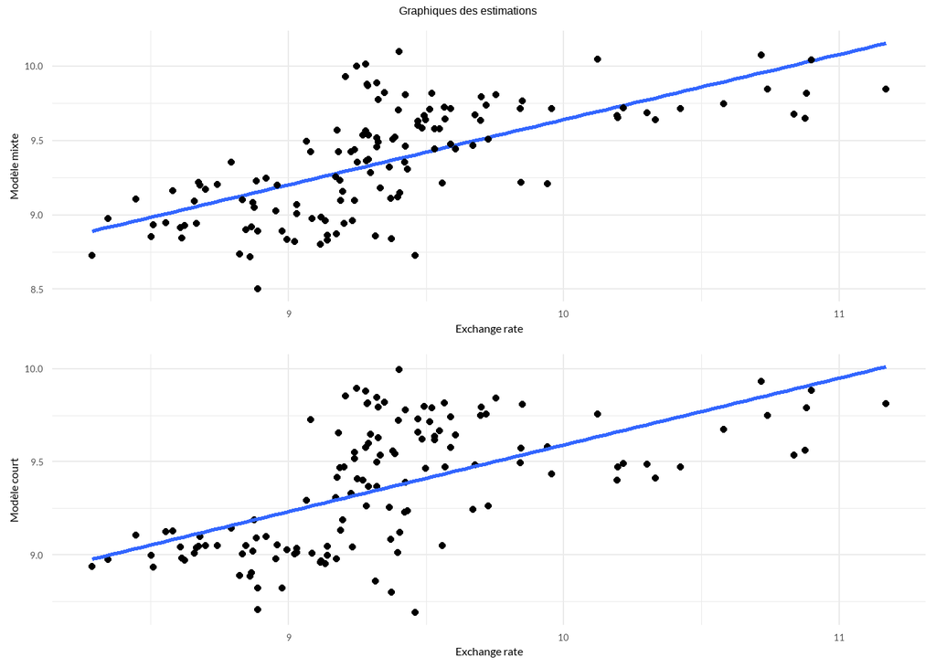

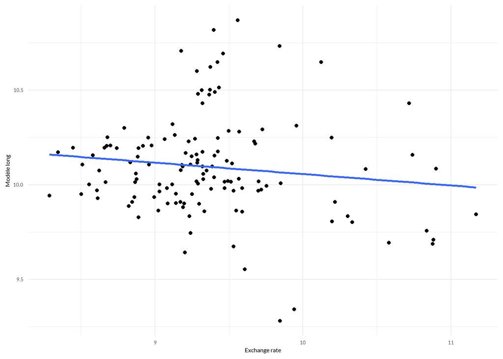

Les conclusions que nous en tirons sont les suivantes.

  Modèle 1 (Pente mixte) => Le différentiel d’inflation est significatif à 10% : il contribue à expliquer les variations du taux de change.

  Modèle 3 (Pente longue) => Le prix du pétrole reste significatif et confirme l’impact des chocs énergétiques sur la SEK mais le différentiel d’inflation est non significatif ici. Le modèle pente longue est le plus robuste des 3, il est donc le plus pertinent pour expliquer le taux de change SEK/EUR, en combinant une intuition économique forte et une excellente performance statistique.